# 01. DESeq2 Pairwise Differential Expression - D. erecta

## 8 Run DESeq2 Analysis

```r
# Estimate size factors, dispersions, and fit the DE model
dds <- DESeq(dds)

# Save normalized counts for later inspection
norm_counts <- counts(dds, normalized = TRUE)
safe_write_csv(
  as.data.frame(norm_counts),
  "normalized_counts_all_species2.csv",
  row.names = TRUE
)

# Use variance-stabilised counts for the heatmaps.
vsd_mat <- assay(vst(dds, blind = FALSE))

print(resultsNames(dds))
```

```
## [1] "Intercept"            "species_Dmel_vs_Dere" "species_Dsan_vs_Dere"
## [4] "species_Dsec_vs_Dere" "species_Dsim_vs_Dere" "species_Dsuz_vs_Dere"
```

The DESeq2 results use a direct threshold test with `lfcThreshold`: genes are called significant only when the adjusted p-value is below the FDR cutoff and the data support an absolute log2 fold change greater than the specified effect-size threshold. The exported `log2FoldChange` column contains apeglm-shrunken estimates, while `raw_log2FoldChange` preserves the unshrunken MLE for auditability. Among significant genes, direction flags are assigned from the sign of the shrunken estimate; the threshold is not applied a second time.

## 10 Run All Pairwise Comparisons Against Dere

```r
comparison_species <- setdiff(levels(sample_info$species), "Dere")
padj_cutoff <- 0.10
strict_padj_cutoff <- 0.05
strict_lfc_cutoff <- 1.00
lfc_cutoff <- 0.50
results_list <- list(); summary_table <- list(); tested_genes_by_contrast <- list()
for (sp in comparison_species) {
  coef_name <- grep(paste0("^species_", sp, "_vs_Dere$"), resultsNames(dds), value = TRUE)
  if (length(coef_name) != 1L) {
    stop("Expected exactly one coefficient matching ", sp, " vs the reference level; found ", length(coef_name), ". apeglm requires `coef`, so the focal species must be the reference level (check the relevel() call).")
  }
  raw_mle <- results(dds, name = coef_name, alpha = padj_cutoff)
  res <- results(dds, name = coef_name, alpha = padj_cutoff, lfcThreshold = lfc_cutoff, altHypothesis = "greaterAbs")
  strict_res <- results(dds, name = coef_name, alpha = strict_padj_cutoff, lfcThreshold = strict_lfc_cutoff, altHypothesis = "greaterAbs")
  shrunk <- lfcShrink(dds, coef = coef_name, res = raw_mle, type = "apeglm")
  res_df <- as.data.frame(res) %>% rownames_to_column("gene")
  raw_df <- as.data.frame(raw_mle) %>% rownames_to_column("gene") %>% dplyr::select(gene, raw_log2FoldChange = log2FoldChange, raw_pvalue = pvalue, raw_padj = padj)
  shr_df <- as.data.frame(shrunk) %>% rownames_to_column("gene") %>% dplyr::select(gene, log2FoldChange)
  strict_df <- as.data.frame(strict_res) %>% rownames_to_column("gene") %>% dplyr::select(gene, strict_padj = padj)
  res_df <- res_df %>% dplyr::rename(threshold_log2FoldChange = log2FoldChange, threshold_pvalue = pvalue, threshold_padj = padj) %>% dplyr::left_join(raw_df, by = "gene") %>% dplyr::left_join(shr_df, by = "gene") %>% dplyr::left_join(strict_df, by = "gene") %>% dplyr::mutate(pvalue = threshold_pvalue, padj = threshold_padj, significant = !is.na(threshold_padj) & threshold_padj < padj_cutoff, significant_strict = !is.na(strict_padj) & strict_padj < strict_padj_cutoff, higher_in_Dere = significant & log2FoldChange < 0, lower_in_Dere = significant & log2FoldChange > 0) %>% dplyr::arrange(padj, dplyr::desc(abs(log2FoldChange)))
  results_list[[sp]] <- res_df
  tested_genes_by_contrast[[sp]] <- res_df$gene[!is.na(res_df$threshold_pvalue)]
  summary_table[[sp]] <- data.frame(comparison = paste0(sp, "_vs_Dere"), genes_tested = sum(!is.na(res_df$threshold_pvalue)), cook_distance_outliers = sum(is.na(raw_mle$pvalue) & !is.na(raw_mle$log2FoldChange)), low_count_independent_filtering = sum(is.na(raw_mle$pvalue) & is.na(raw_mle$log2FoldChange)), significant_genes = sum(res_df$significant, na.rm = TRUE), significant_genes_strict = sum(res_df$significant_strict, na.rm = TRUE), higher_in_Dere = sum(res_df$higher_in_Dere, na.rm = TRUE), lower_in_Dere = sum(res_df$lower_in_Dere, na.rm = TRUE))
  safe_write_csv(res_df, paste0("DESeq2_", sp, "_vs_Dere.csv"), row.names = FALSE)
}
contrast_summary <- dplyr::bind_rows(summary_table)
stopifnot(all(contrast_summary$significant_genes == contrast_summary$higher_in_Dere + contrast_summary$lower_in_Dere))
zero_shrunken_by_contrast <- dplyr::bind_rows(lapply(names(results_list), function(sp) data.frame(comparison = paste0(sp, "_vs_Dere"), significant_shrunken_log2FC_exactly_zero = sum(results_list[[sp]]$significant & results_list[[sp]]$log2FoldChange == 0, na.rm = TRUE))))
zero_shrunken_by_contrast
```

| comparison | significant_shrunken_log2FC_exactly_zero |
| --- | --- |
| Dmel_vs_Dere | 0 |
| Dsan_vs_Dere | 0 |
| Dsec_vs_Dere | 0 |
| Dsim_vs_Dere | 0 |
| Dsuz_vs_Dere | 0 |

```r
contrast_summary
```

| comparison | genes_tested | cook_distance_outliers | low_count_independent_filtering | significant_genes | significant_genes_strict | higher_in_Dere | lower_in_Dere |
| --- | --- | --- | --- | --- | --- | --- | --- |
| Dmel_vs_Dere | 9813 | 36 | 0 | 1136 | 445 | 600 | 536 |
| Dsan_vs_Dere | 9813 | 36 | 0 | 1374 | 470 | 717 | 657 |
| Dsec_vs_Dere | 9813 | 36 | 0 | 1168 | 404 | 504 | 664 |
| Dsim_vs_Dere | 9813 | 36 | 0 | 1369 | 512 | 781 | 588 |
| Dsuz_vs_Dere | 9813 | 36 | 0 | 1770 | 796 | 1016 | 754 |

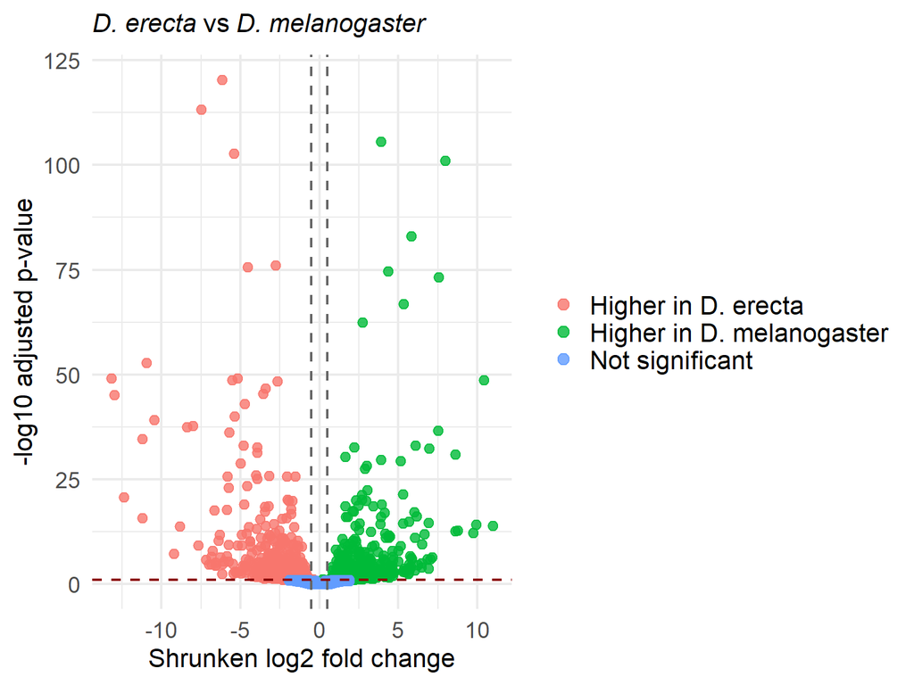

Volcano plots for each species relative to D. erecta.

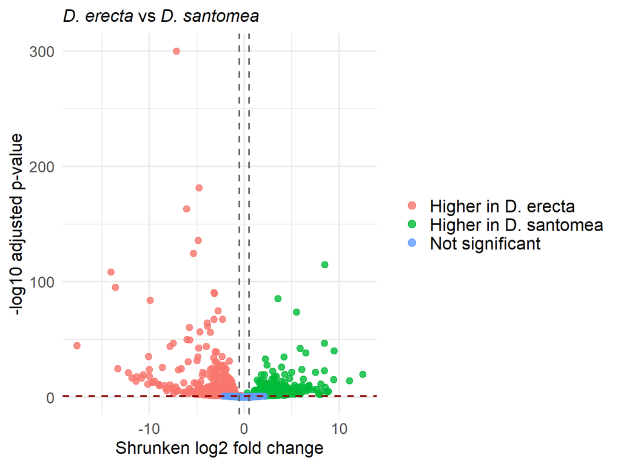

Volcano plots for each species relative to D. erecta.

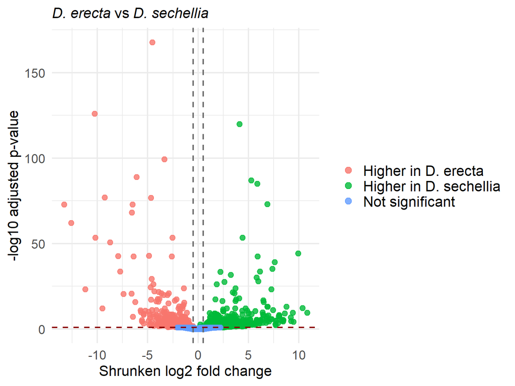

Volcano plots for each species relative to D. erecta.

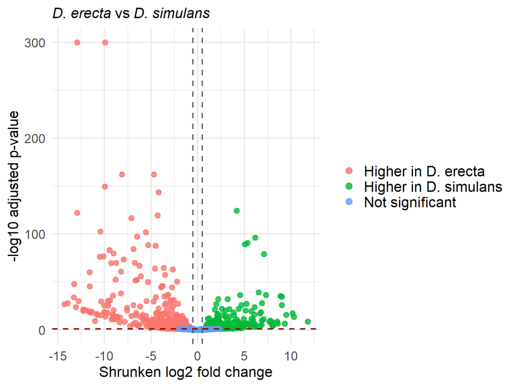

Volcano plots for each species relative to D. erecta.

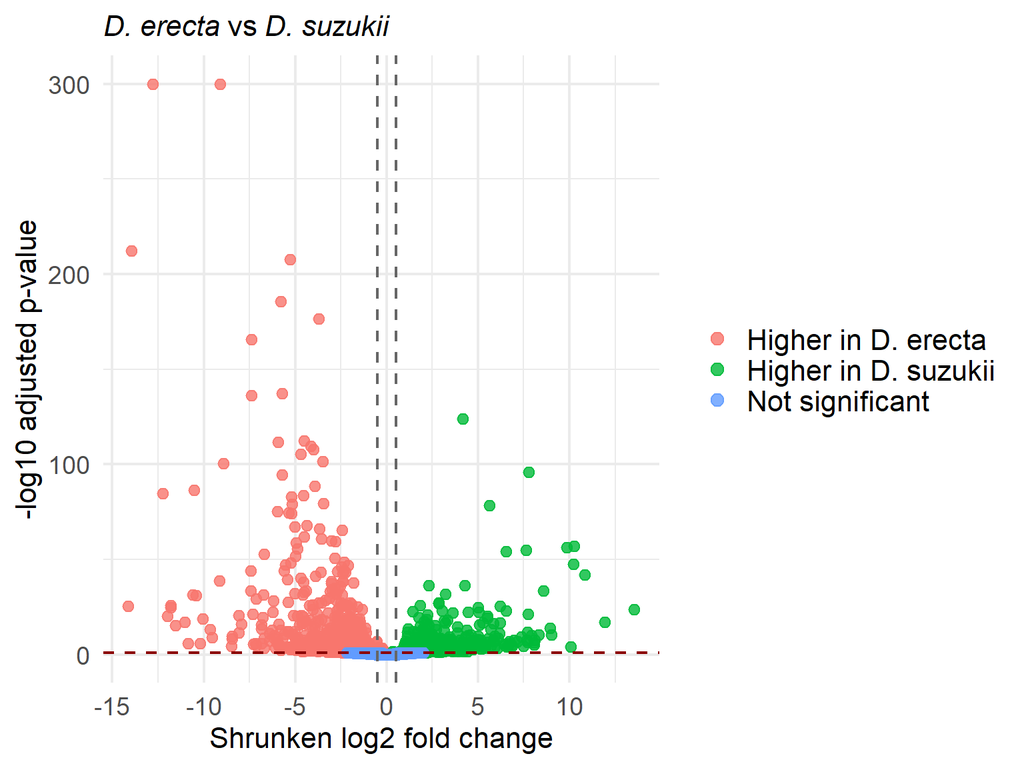

Volcano plots for each species relative to D. erecta.

```r
# Full scientific names used in plot labels.
species_names <- c(
  Dere = "D. erecta",
  Dmel = "D. melanogaster",
  Dsim = "D. simulans",
  Dsec = "D. sechellia",
  Dsan = "D. santomea",
  Dsuz = "D. suzukii"
)

# Set these three values according to the script's reference species.
reference_code <- "Dere"
reference_label <- species_names[[reference_code]]
higher_reference_column <- "higher_in_Dere"
lower_reference_column <- "lower_in_Dere"

plot_volcano <- function(x, sp) {

  comparison_label <- species_names[[sp]]

  d <- x %>%
    mutate(
      y = -log10(pmax(padj, 1e-300)),
      status = case_when(
        .data[[higher_reference_column]] ~
          paste("Higher in", reference_label),
        .data[[lower_reference_column]] ~
          paste("Higher in", comparison_label),
        TRUE ~ "Not significant"
      )
    )

  plot_title <- bquote(
    italic(.(reference_label)) ~ "vs" ~ italic(.(comparison_label))
  )

  ggplot(d, aes(log2FoldChange, y, colour = status)) +
    geom_point(alpha = 0.80, size = 2.5) +
    geom_vline(
      xintercept = c(-lfc_cutoff, lfc_cutoff),
      linetype = "dashed",
      colour = "grey40"
    ) +
    geom_hline(
      yintercept = -log10(padj_cutoff),
      linetype = "dashed",
      colour = "red4"
    ) +
    theme_minimal(base_size = 16) +
    labs(
      title = plot_title,
      x = "Shrunken log2 fold change",
      y = "-log10 adjusted p-value",
      colour = NULL
    ) +
    theme(
      plot.title = element_text(size = 16),
      axis.title = element_text(size = 16),
      axis.text = element_text(size = 14),
      legend.text = element_text(size = 16)
    ) +
    guides(colour = guide_legend(override.aes = list(size = 3)))
}

for (sp in comparison_species) {
  print(plot_volcano(results_list[[sp]], sp))
}
```

## 11 Heatmaps for All Comparisons

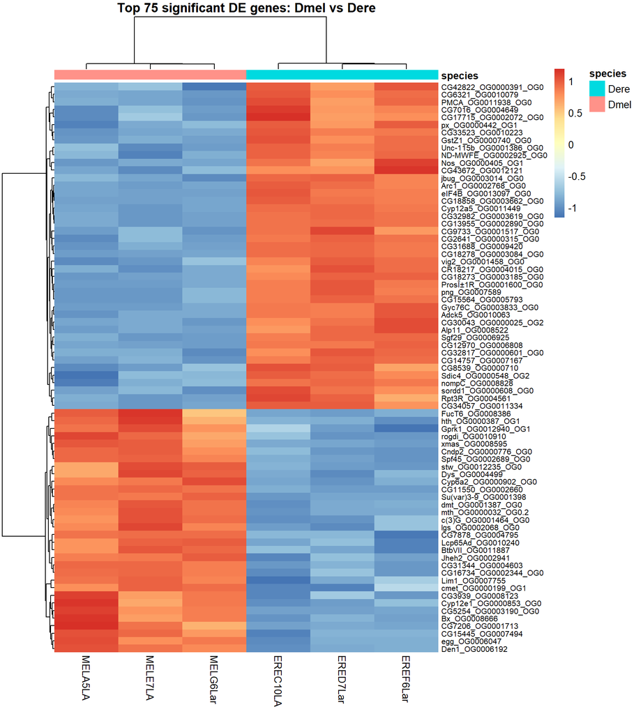

Top-75 significant-gene heatmaps; complete matrices are supplied as CSV files for each D. erecta contrast.

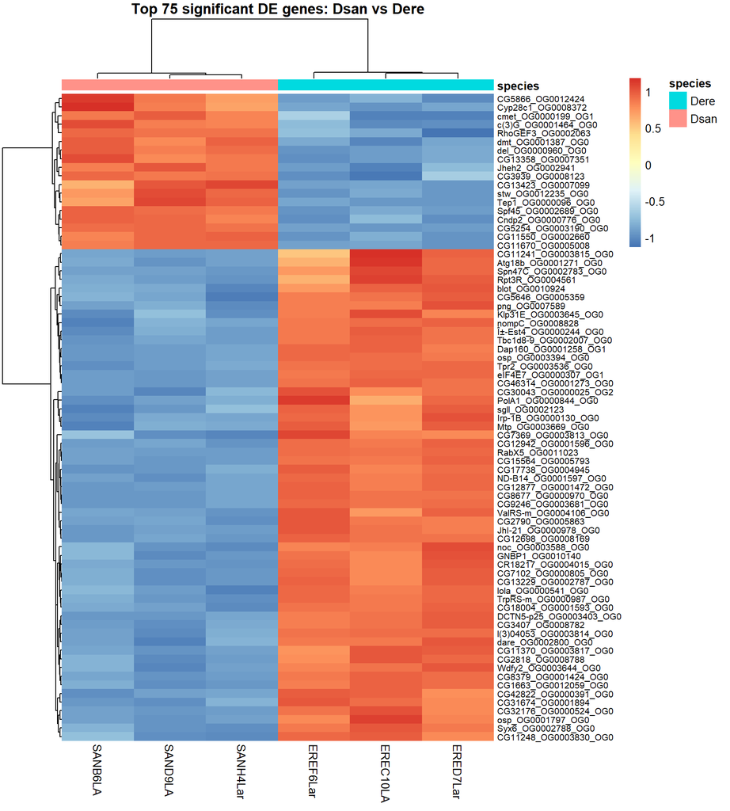

Top-75 significant-gene heatmaps; complete matrices are supplied as CSV files for each D. erecta contrast.

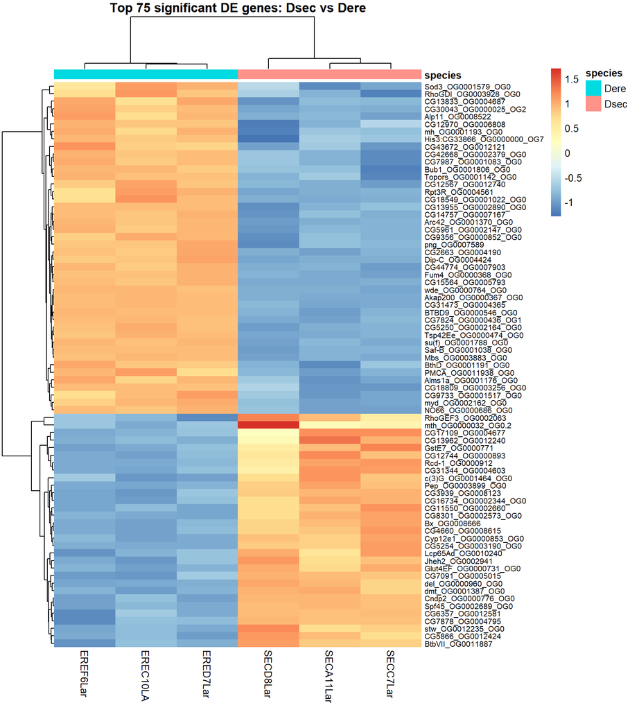

Top-75 significant-gene heatmaps; complete matrices are supplied as CSV files for each D. erecta contrast.

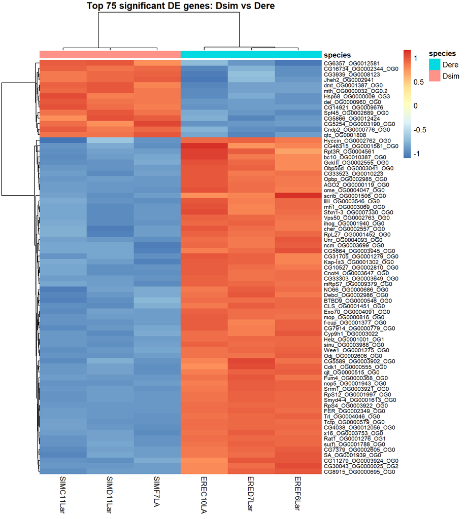

Top-75 significant-gene heatmaps; complete matrices are supplied as CSV files for each D. erecta contrast.

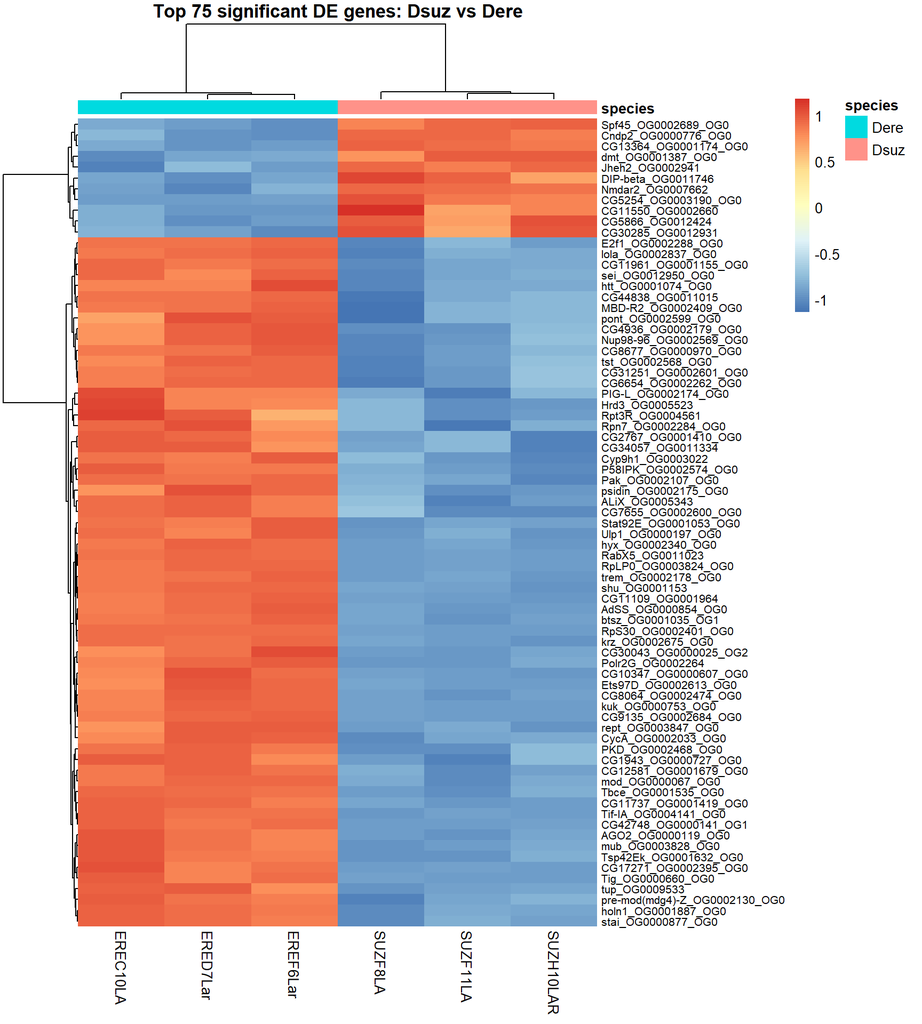

Top-75 significant-gene heatmaps; complete matrices are supplied as CSV files for each D. erecta contrast.

```r
# Create a folder for complete scaled heatmap matrices and gene-order tables.
heatmap_output_dir <- "all_significant_gene_heatmaps2"
dir.create(heatmap_output_dir, recursive = TRUE, showWarnings = FALSE)

# Draw one heatmap per contrast using every significant gene from that contrast.
for (sp in comparison_species) {
  # Retrieve the complete differential-expression table for this comparison.
  res_df <- results_list[[sp]]

  # Keep all significant genes, ordered by adjusted p-value before clustering.
  heatmap_genes <- res_df %>%
    dplyr::filter(significant) %>%
    dplyr::arrange(padj, dplyr::desc(abs(log2FoldChange))) %>%
    dplyr::pull(gene)

  # Skip the plot cleanly if a contrast has fewer than two significant genes.
  if (length(heatmap_genes) < 2) {
    cat("Skipping heatmap for", sp, "because fewer than 2 significant genes were found.
")
    next
  }

  # Keep samples from D. erecta and the focal comparison species.
  keep_samples <- rownames(sample_info)[sample_info$species %in% c("Dere", sp)]
  heat_mat <- vsd_mat[heatmap_genes, keep_samples, drop = FALSE]

  # Remove zero-variance genes because row scaling would convert them to NA values.
  row_sd <- apply(heat_mat, 1, stats::sd, na.rm = TRUE)
  variable_rows <- is.finite(row_sd) & row_sd > 0
  heat_mat <- heat_mat[variable_rows, , drop = FALSE]

  # Skip safely if fewer than two variable genes remain after quality control.
  if (nrow(heat_mat) < 2) {
    cat("Skipping heatmap for", sp, "because fewer than 2 variable genes remain.
")
    next
  }

  # Standardise each gene so heatmap colours represent relative expression.
  heat_mat <- t(scale(t(heat_mat)))

  # Export the complete scaled matrix so every plotted gene remains reviewable.
  safe_write_csv(
    as.data.frame(heat_mat),
    file.path(heatmap_output_dir, paste0(sp, "_vs_Dere_ALL_significant_heatmap_matrix.csv")),
    row.names = TRUE
  )

  # The CSV above retains every significant gene; the plotted heatmap is capped at the top 75 for readability.
  heat_mat <- heat_mat[seq_len(min(75, nrow(heat_mat))), , drop = FALSE]
  # Scale row labels automatically between 1 and 10 points for improved readability.
  heatmap_fontsize <- max(1, min(10, 600 / nrow(heat_mat)))

  # Draw the complete heatmap; clustering determines the displayed gene order.
  heatmap_obj <- pheatmap(
    heat_mat,
    annotation_col = sample_info[keep_samples, "species", drop = FALSE],
    show_rownames = TRUE, show_colnames = TRUE, fontsize_row = heatmap_fontsize, border_color = NA,
    main = paste("Top 75 significant DE genes:", sp, "vs Dere"), silent = TRUE
  )
  grid::grid.newpage(); grid::grid.draw(heatmap_obj$gtable)
  png(file.path(heatmap_output_dir, paste0(sp, "_vs_Dere_ALL_significant_heatmap.png")), width=900, height=1000, res=120)
  grid::grid.newpage(); grid::grid.draw(heatmap_obj$gtable); invisible(dev.off())
}
```

## 12 Save Inputs for Part 2 - Erecta

The second report loads one compact RDS file, so the DESeq2 model does not need to be fitted again before GO enrichment.

```r
# Store only the objects required by the separate GO enrichment report.
go_input_objects <- list(
  results_list = results_list,
  comparison_species = comparison_species,
  tested_genes_by_contrast = tested_genes_by_contrast,
  padj_cutoff = padj_cutoff,
  lfc_cutoff = lfc_cutoff
)

# Save the reusable handoff file beside both R Markdown documents.
saveRDS(go_input_objects, "deseq2_GO_input_objects.rds2")

# Confirm where the handoff file was saved and how many contrasts it contains.
data.frame(
  handoff_file = normalizePath(
    "deseq2_GO_input_objects.rds2",
    winslash = "/",
    mustWork = FALSE
  ),
  tested_genes_by_contrast = vapply(go_input_objects$tested_genes_by_contrast, length, integer(1)),
  contrasts = length(go_input_objects$results_list)
)
```

|  | handoff_file | tested_genes_by_contrast | contrasts |
| --- | --- | --- | --- |
| Dmel | D:/Bioinformatics/Research-Project-Brain-Evolution_precommit/erecta/deseq2_GO_input_objects.rds2 | 9813 | 5 |
| Dsan | D:/Bioinformatics/Research-Project-Brain-Evolution_precommit/erecta/deseq2_GO_input_objects.rds2 | 9813 | 5 |
| Dsec | D:/Bioinformatics/Research-Project-Brain-Evolution_precommit/erecta/deseq2_GO_input_objects.rds2 | 9813 | 5 |
| Dsim | D:/Bioinformatics/Research-Project-Brain-Evolution_precommit/erecta/deseq2_GO_input_objects.rds2 | 9813 | 5 |
| Dsuz | D:/Bioinformatics/Research-Project-Brain-Evolution_precommit/erecta/deseq2_GO_input_objects.rds2 | 9813 | 5 |